# Welcome to BIOS 567

Mikhail Dozmorov

Fall 2016

# Course logistics

**Instructor**: Mikhail G. Dozmorov mikhail.dozmorov@vcuhealth.org, Ph.D.; Jin Liu (TA)

**Schedule**: Monday, Wednesday 1:00pm – 2:20pm

**Classroom**: One Capital Square (OCS) 5009

**Office hours**: Mon, Wed 2:30pm – 4:00pm, OCS 730; TA: Mon, Wed 10:30am - 12:00pm

**Course documents**: https://blackboard.vcu.edu, https://mdozmorov.github.io/BIOS567/

# Course prerequisites

**Prerequisites**: BIOS 524 Biostatistical Computing, BIOS 553 Linear Regression, and BIOS 554 ANOVA

**Required text**: Sorin Draghici “Statistics and Data Analysis for Microarrays Using R and Bioconductor”, 2nd Ed., Chapman & Hall/CRC Press, 2012. ISBN-978-1-4398-0975-4, Supplemental course materials provided in-class

**Software**: The R programming environment

# Computational Genomics

**Genomics/Bioinformatics (general)**

- Generation, organization, and analysis of biological data (initially genomic data)

**Biostatistics**

- Class of statistical methods for dealing with large biological data sets
- Goal: statistically identify significant changes in biological processes to answer relevant biological questions.
- High-throughput studies; get data matrix; mine the matrix for information

# Bioinformatics

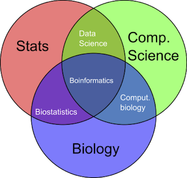

Data Scientist = statistician + programmer + coach + storyteller + artist

- Shlomo Aragmon

https://genomejigsaw.wordpress.com/2015/09/27/faq

# Microarrays

Counts of papers per year in PubMed having `microarray` word

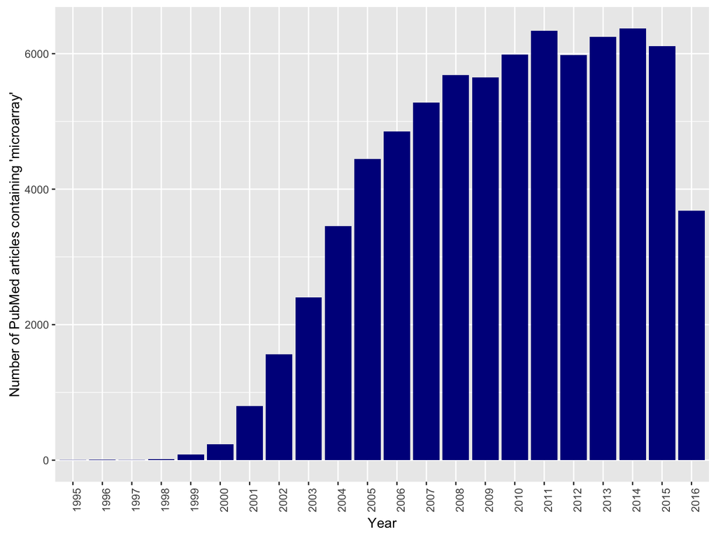